[figure not shown]

# Day 4

## Review

- Bias-Variance trade-off
- $v$-fold cross validation

## CART

- [Decision Tree: The Obama-Clinton Divide](https://archive.nytimes.com/www.nytimes.com/imagepages/2008/04/16/us/20080416_OBAMA_GRAPHIC.html?scp=5&sq=Decision%20Obama%20clinton&st=cse)
- [R2D3: Intro to Machine Learning](http://www.r2d3.us/visual-intro-to-machine-learning-part-1/)

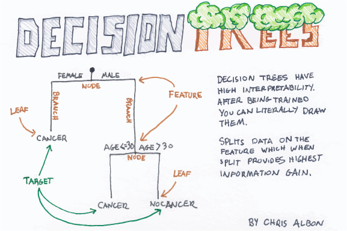

**Source:** [Chris Albon](https://machinelearningflashcards.com/)

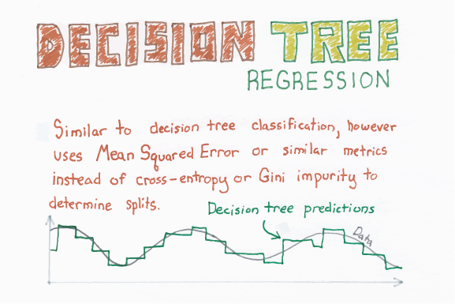

**Source:** [Chris Albon](https://machinelearningflashcards.com/)

## New functions

- `v_fold_cv()`
- `tune()`
- `decision_tree()`
- `tune_grid()`
- `collect_metrics()`
- `collect_predictions()`
- `select_best()`

## Exercise 1

```r
library(tidyverse)
library(tidymodels)
```

### Step 0. Load the data

```r
set.seed(20201005)

x1 <- runif(n = 1000, min = 0, max = 10)
x2 <- runif(n = 1000, min = 10, max = 20)

data1 <- bind_cols(
  x1 = x1,
  x2 = x2,
  y = 10 * sin(x1) + x2 + 20 + rnorm(n = length(x1), mean = 0, sd = 2)
)
```

### Step 1. Split the data into training and testing data

```r
set.seed(20201007)

# create a split object
data1_split <- initial_split(data = data1, prop = 0.75)

# create the training and testing data
data1_train <- training(x = data1_split)
data1_test  <- testing(x = data1_split)
```

### Step 2. EDA

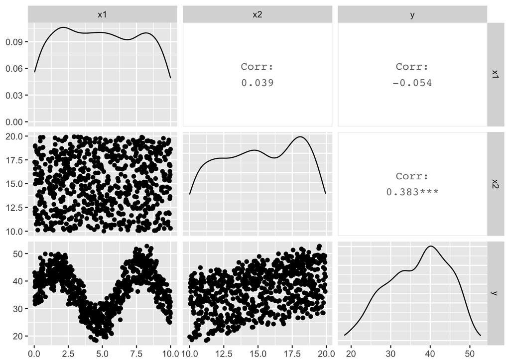

```r
GGally::ggpairs(data = data1_train)
```

### Step 3. Create a Recipe

$x_1$ and $x_2$ are not on the same scale. It is important to *normalize* both variables before model estimation.

```r
knn_recipe <-
  recipe(formula = y ~ ., data = data1_train) %>%
  step_normalize(x1, x2)
```

### Step 4. Create resamples

This creates a data structure with 10 v-folds.

```r
folds <- vfold_cv(data = data1_train, v = 10)

folds
```

```
## #  10-fold cross-validation
## # A tibble: 10 x 2
##    splits           id
##    <list>           <chr>
##  1 <split [675/75]> Fold01
##  2 <split [675/75]> Fold02
##  3 <split [675/75]> Fold03
##  4 <split [675/75]> Fold04
##  5 <split [675/75]> Fold05
##  6 <split [675/75]> Fold06
##  7 <split [675/75]> Fold07
##  8 <split [675/75]> Fold08
##  9 <split [675/75]> Fold09
## 10 <split [675/75]> Fold10
```

### Step 5. Create a model

Instead of specifying `neighbors = 5`, use `tune()` as a placeholder so the different values of $k$ can be passed to the model during hyperparameter tuning.

```r
# create a knn model specification
# knn_mod <-
#   nearest_neighbor(neighbors = 5) %>%
#   set_engine(engine = "kknn") %>%
#   set_mode(mode = "regression")

# create a knn model specification
knn_mod <-
  nearest_neighbor(neighbors = tune()) %>%
  set_engine(engine = "kknn") %>%
  set_mode(mode = "regression")
```

### Step 6. Create a workflow

```r
knn_workflow <-
  workflow() %>%
  add_model(spec = knn_mod) %>%
  add_recipe(recipe = knn_recipe)
```

### Step 7. Create a tuning grid

Create a tuning grid for values of hyperparameters ranging from 1 to 15 by twos. It is common to use odd values of $k$ to limit ties.

```r
knn_grid <- tibble(neighbors = seq(from = 1, to = 15, by = 2))

knn_grid
```

```
## # A tibble: 8 x 1
##   neighbors
##       <dbl>
## 1         1
## 2         3
## 3         5
## 4         7
## 5         9
## 6        11
## 7        13
## 8        15
```

### Step 8. Estimate models with resampling for each row in the tuning grid

```r
knn_res <-
  knn_workflow %>%
  tune_grid(resamples = folds,
            grid = knn_grid,
            control = control_grid(save_pred = TRUE),
            metrics = metric_set(rmse))
```

### Evaluate the model

```r
# look at summaries
knn_res %>%
  collect_metrics()
```

```
## # A tibble: 8 x 7
##   neighbors .metric .estimator  mean     n std_err .config
##       <dbl> <chr>   <chr>      <dbl> <int>   <dbl> <fct>
## 1         1 rmse    standard    2.95    10  0.0792 Preprocessor1_Model1
## 2         3 rmse    standard    2.50    10  0.0741 Preprocessor1_Model2
## 3         5 rmse    standard    2.38    10  0.0731 Preprocessor1_Model3
## 4         7 rmse    standard    2.35    10  0.0735 Preprocessor1_Model4
## 5         9 rmse    standard    2.35    10  0.0703 Preprocessor1_Model5
## 6        11 rmse    standard    2.36    10  0.0674 Preprocessor1_Model6
## 7        13 rmse    standard    2.37    10  0.0646 Preprocessor1_Model7
## 8        15 rmse    standard    2.39    10  0.0647 Preprocessor1_Model8
```

```r
# look at individual values
knn_res %>%
  collect_metrics(summarize = FALSE)
```

```
## # A tibble: 80 x 6
##    id     neighbors .metric .estimator .estimate .config
##    <chr>      <dbl> <chr>   <chr>          <dbl> <fct>
##  1 Fold01         1 rmse    standard        2.92 Preprocessor1_Model1
##  2 Fold02         1 rmse    standard        2.78 Preprocessor1_Model1
##  3 Fold03         1 rmse    standard        2.73 Preprocessor1_Model1
##  4 Fold04         1 rmse    standard        2.72 Preprocessor1_Model1
##  5 Fold05         1 rmse    standard        3.28 Preprocessor1_Model1
##  6 Fold06         1 rmse    standard        2.70 Preprocessor1_Model1
##  7 Fold07         1 rmse    standard        2.84 Preprocessor1_Model1
##  8 Fold08         1 rmse    standard        3.44 Preprocessor1_Model1
##  9 Fold09         1 rmse    standard        3.04 Preprocessor1_Model1
## 10 Fold10         1 rmse    standard        2.97 Preprocessor1_Model1
## # … with 70 more rows
```

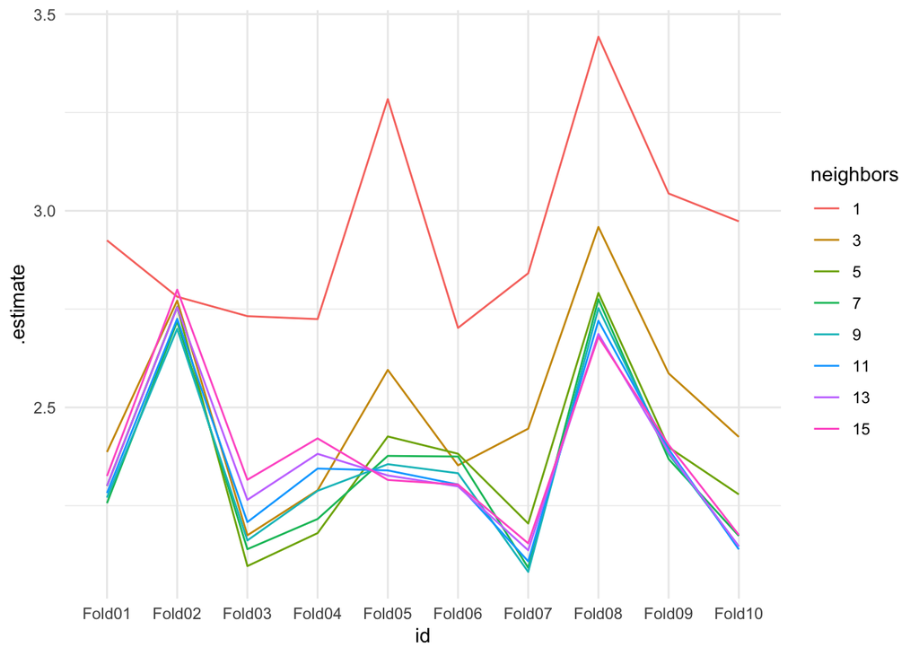

```r
# make a plot
knn_res %>%
  collect_metrics(summarize = FALSE) %>%
  mutate(neighbors = factor(neighbors)) %>%
  ggplot(aes(id, .estimate, color = neighbors, group = neighbors)) +
  geom_line() +
  theme_minimal()
```

```r
# pick the best model
knn_res %>%
  select_best()
```

```
## # A tibble: 1 x 2
##   neighbors .config
##       <dbl> <fct>
## 1         9 Preprocessor1_Model5
```

```r
# look at predicted values from the resamples
knn_res %>%
  collect_predictions()
```

```
## # A tibble: 6,000 x 6
##    id     .pred  .row neighbors     y .config
##    <chr>  <dbl> <int>     <dbl> <dbl> <fct>
##  1 Fold01  28.5     5         1  28.6 Preprocessor1_Model1
##  2 Fold01  42.6    19         1  48.5 Preprocessor1_Model1
##  3 Fold01  32.9    22         1  30.1 Preprocessor1_Model1
##  4 Fold01  39.3    23         1  34.3 Preprocessor1_Model1
##  5 Fold01  39.9    31         1  45.4 Preprocessor1_Model1
##  6 Fold01  46.5    55         1  46.8 Preprocessor1_Model1
##  7 Fold01  45.4    58         1  48.3 Preprocessor1_Model1
##  8 Fold01  41.2    73         1  46.8 Preprocessor1_Model1
##  9 Fold01  37.3    85         1  38.8 Preprocessor1_Model1
## 10 Fold01  43.4    88         1  45.9 Preprocessor1_Model1
## # … with 5,990 more rows
```

From here, it is possible to estimate the model with the optimal $k = 9$ on all of the training data, get one estimate of $\hat{RMSE}$ using the testing data, and then make predictions on new data.

## Exercise 2

An illness has affected penguins near Palmer Station, Antarctica. We have a limited amount of medicine (5 doses) and the illness is much more damaging to penguins with low body mass. We have an historical data set with mass but we don’t have a way to weigh the penguins near the stations.

```r
library(palmerpenguins)

penguins <- penguins %>%
  filter(complete.cases(.)) %>%
  select(-year)

penguins_new <- penguins[c(104, 92, 253, 8, 256, 88, 30, 119, 216, 251),
                         names(penguins) != "body_mass_g"]
```

Use CART and 10-fold cross validation to estimate a model, estimate the out-of-sample error rate, and predict the mass of `penguins_new`.